# The pandas library

pandas is a data analysis toolkit for Python. It makes it easy to work with certain types of data, especially:

- Tabular data (i.e., anything that can be expressed as labelled columns and rows)
- Time series data
- Matrix data
- Statistical datasets

We will see some of pandas' features by working with a dataset of 311 service requests from New York City. This data is stored in a CSV file, which you can open with most spreadsheet software.

(Open 311-service-requests.csv in LibreOffice/Excel/etc.)

- Unique Key: A unique identifier for the service call
- Created Date
- Agency / Agency Name
- Complaint Type / Descriptor
- Incident Address

Given this data, let's say we wanted to answer the following questions:

1. What are the top 10 complaint types?
2. How many noise complaints were there in a given borough?
3. What is the top complaint in each borough?

We can answer these questions with what we've already seen in Python. For example:

- We could load this data into a list of complaints using the csv DictReader class, so each complaint is represented as a dictionary,
- and then use loops to process that data.
- Or we could make a `Complaint` class and represent each complaint as an instance of that class.

However, pandas provides us with higher-level abstractions that will make it much easier to answer these questions. On top of that, pandas also handles many aspects of working with real-world data sets, like dealing with missing data or converting data to the right type (if we read the file manually, we would start with strings for everything, and would have to make sure everything was converted to the right type).

To import the pandas library we do this:

```python
import pandas as pd
```

# DataFrames

The most important data structure in pandas is the `DataFrame`, which represents tabular data. Tabular data is like a table with rows and columns, like the 311 data.

In tabular data, every column always has a "name". In the 311 CSV file in the spreadsheet, the name of each column is the header of each column.

Rows can also have unique labels (this is called an "index"). This allows us to refer to individual rows by some unique identifier. By default, pandas will label the rows 0, 1, etc. for us (i.e., rows are numbered from zero).

So, we are going to load the 311 CSV file using the `read_csv` function.

```python
complaints = pd.read_csv("311-service-requests.csv")
```

`complaints` is a DataFrame. You can think of it as containing a table representing the data in the file. Notice that it automatically detected that the first row contains the column labels.

```python
complaints
```

|  | Unique Key | Created Date | Closed Date | Agency | Agency Name | Complaint Type | Descriptor | Location Type | Incident Zip | Incident Address | ... | Bridge Highway Name | Bridge Highway Direction | Road Ramp | Bridge Highway Segment | Garage Lot Name | Ferry Direction | Ferry Terminal Name | Latitude | Longitude | Location |
| --- | --- | --- | --- | --- | --- | --- | --- | --- | --- | --- | --- | --- | --- | --- | --- | --- | --- | --- | --- | --- | --- |
| 0 | 26589651 | 10/31/2013 02:08:41 AM | NaN | NYPD | New York City Police Department | Noise - Street/Sidewalk | Loud Talking | Street/Sidewalk | 11432.0 | 90-03 169 STREET | ... | NaN | NaN | NaN | NaN | NaN | NaN | NaN | 40.708275 | -73.791604 | (40.70827532593202, -73.79160395779721) |
| 1 | 26593698 | 10/31/2013 02:01:04 AM | NaN | NYPD | New York City Police Department | Illegal Parking | Commercial Overnight Parking | Street/Sidewalk | 11378.0 | 58 AVENUE | ... | NaN | NaN | NaN | NaN | NaN | NaN | NaN | 40.721041 | -73.909453 | (40.721040535628305, -73.90945306791765) |
| 2 | 26594139 | 10/31/2013 02:00:24 AM | 10/31/2013 02:40:32 AM | NYPD | New York City Police Department | Noise - Commercial | Loud Music/Party | Club/Bar/Restaurant | 10032.0 | 4060 BROADWAY | ... | NaN | NaN | NaN | NaN | NaN | NaN | NaN | 40.843330 | -73.939144 | (40.84332975466513, -73.93914371913482) |
| 3 | 26595721 | 10/31/2013 01:56:23 AM | 10/31/2013 02:21:48 AM | NYPD | New York City Police Department | Noise - Vehicle | Car/Truck Horn | Street/Sidewalk | 10023.0 | WEST 72 STREET | ... | NaN | NaN | NaN | NaN | NaN | NaN | NaN | 40.778009 | -73.980213 | (40.7780087446372, -73.98021349023975) |
| 4 | 26590930 | 10/31/2013 01:53:44 AM | NaN | DOHMH | Department of Health and Mental Hygiene | Rodent | Condition Attracting Rodents | Vacant Lot | 10027.0 | WEST 124 STREET | ... | NaN | NaN | NaN | NaN | NaN | NaN | NaN | 40.807691 | -73.947387 | (40.80769092704951, -73.94738703491433) |
| ... | ... | ... | ... | ... | ... | ... | ... | ... | ... | ... | ... | ... | ... | ... | ... | ... | ... | ... | ... | ... | ... |
| 111064 | 26426013 | 10/04/2013 12:01:13 AM | 10/07/2013 04:07:16 PM | DPR | Department of Parks and Recreation | Maintenance or Facility | Structure - Outdoors | Park | 11213.0 | NaN | ... | NaN | NaN | NaN | NaN | NaN | NaN | NaN | NaN | NaN | NaN |
| 111065 | 26428083 | 10/04/2013 12:01:05 AM | 10/04/2013 02:13:50 AM | NYPD | New York City Police Department | Illegal Parking | Posted Parking Sign Violation | Street/Sidewalk | 11434.0 | NaN | ... | NaN | NaN | NaN | NaN | NaN | NaN | NaN | 40.656160 | -73.767353 | (40.656160351546845, -73.76735262738222) |
| 111066 | 26428987 | 10/04/2013 12:00:45 AM | 10/04/2013 01:25:01 AM | NYPD | New York City Police Department | Noise - Street/Sidewalk | Loud Talking | Street/Sidewalk | 10016.0 | 344 EAST 28 STREET | ... | NaN | NaN | NaN | NaN | NaN | NaN | NaN | 40.740295 | -73.976952 | (40.740295354643706, -73.97695165980414) |
| 111067 | 26426115 | 10/04/2013 12:00:28 AM | 10/04/2013 04:17:32 AM | NYPD | New York City Police Department | Noise - Commercial | Loud Talking | Club/Bar/Restaurant | 11226.0 | 1233 FLATBUSH AVENUE | ... | NaN | NaN | NaN | NaN | NaN | NaN | NaN | 40.640182 | -73.955306 | (40.64018174662485, -73.95530566958138) |
| 111068 | 26428033 | 10/04/2013 12:00:10 AM | 10/04/2013 01:20:52 AM | NYPD | New York City Police Department | Blocked Driveway | Partial Access | Street/Sidewalk | 11236.0 | 1259 EAST 94 STREET | ... | NaN | NaN | NaN | NaN | NaN | NaN | NaN | 40.640024 | -73.900717 | (40.640024057399216, -73.90071711703163) |

111069 rows × 52 columns

Here are a few basic operations on DataFrames.

Get all the column names (we're going to want to use "Complaint Type" and "Borough"):

```python
complaints.columns # Column names
```

```
Index(['Unique Key', 'Created Date', 'Closed Date', 'Agency', 'Agency Name',
       'Complaint Type', 'Descriptor', 'Location Type', 'Incident Zip',
       'Incident Address', 'Street Name', 'Cross Street 1', 'Cross Street 2',
       'Intersection Street 1', 'Intersection Street 2', 'Address Type',
       'City', 'Landmark', 'Facility Type', 'Status', 'Due Date',
       'Resolution Action Updated Date', 'Community Board', 'Borough',
       'X Coordinate (State Plane)', 'Y Coordinate (State Plane)',
       'Park Facility Name', 'Park Borough', 'School Name', 'School Number',
       'School Region', 'School Code', 'School Phone Number', 'School Address',
       'School City', 'School State', 'School Zip', 'School Not Found',
       'School or Citywide Complaint', 'Vehicle Type', 'Taxi Company Borough',
       'Taxi Pick Up Location', 'Bridge Highway Name',
       'Bridge Highway Direction', 'Road Ramp', 'Bridge Highway Segment',
       'Garage Lot Name', 'Ferry Direction', 'Ferry Terminal Name', 'Latitude',
       'Longitude', 'Location'],
      dtype='object')
```

Get the number of rows and columns (there are over 100,000 complaints in this dataset):

```python
complaints.shape # rows x columns
# Over 100,000 complaints
```

```
(111069, 52)
```

We can access an individual column using square brackets. This returns a `Series` object, which represents a one-dimensional labelled array.

```python
complaints["Complaint Type"] # Get the "Complaint Type" column
```

```
0         Noise - Street/Sidewalk
1                 Illegal Parking
2              Noise - Commercial
3                 Noise - Vehicle
4                          Rodent
                   ...
111064    Maintenance or Facility
111065            Illegal Parking
111066    Noise - Street/Sidewalk
111067         Noise - Commercial
111068           Blocked Driveway
Name: Complaint Type, Length: 111069, dtype: object
```

However, if we select multiple columns, we get back a DataFrame:

```python
complaints[["Complaint Type", "Borough"]] # Ask for "Complaint Type" and "Borough"
# This is like fancy indexing in NumPy (index into a DF with a list of column names)
```

|  | Complaint Type | Borough |
| --- | --- | --- |
| 0 | Noise - Street/Sidewalk | QUEENS |
| 1 | Illegal Parking | QUEENS |
| 2 | Noise - Commercial | MANHATTAN |
| 3 | Noise - Vehicle | MANHATTAN |
| 4 | Rodent | MANHATTAN |
| ... | ... | ... |
| 111064 | Maintenance or Facility | BROOKLYN |
| 111065 | Illegal Parking | QUEENS |
| 111066 | Noise - Street/Sidewalk | MANHATTAN |
| 111067 | Noise - Commercial | BROOKLYN |
| 111068 | Blocked Driveway | BROOKLYN |

111069 rows × 2 columns

We can access an individual row using its label:

```python
complaints.loc[10]
```

```
Unique Key                                                       26595176
Created Date                                       10/31/2013 01:25:12 AM
Closed Date                                                           NaN
Agency                                                               NYPD
Agency Name                               New York City Police Department
Complaint Type                                   Noise - House of Worship
Descriptor                                               Loud Music/Party
Location Type                                            House of Worship
Incident Zip                                                      11218.0
Incident Address                                           3775 18 AVENUE
Street Name                                                     18 AVENUE
Cross Street 1                                              EAST 9 STREET
Cross Street 2                                              EAST 8 STREET
Intersection Street 1                                                 NaN
Intersection Street 2                                                 NaN
Address Type                                                      ADDRESS
City                                                             BROOKLYN
Landmark                                                              NaN
Facility Type                                                    Precinct
Status                                                               Open
Due Date                                           10/31/2013 09:25:12 AM
Resolution Action Updated Date                                        NaN
Community Board                                               14 BROOKLYN
Borough                                                          BROOKLYN
X Coordinate (State Plane)                                       992726.0
Y Coordinate (State Plane)                                       170399.0
Park Facility Name                                            Unspecified
Park Borough                                                     BROOKLYN
School Name                                                   Unspecified
School Number                                                 Unspecified
School Region                                                 Unspecified
School Code                                                   Unspecified
School Phone Number                                           Unspecified
School Address                                                Unspecified
School City                                                   Unspecified
School State                                                  Unspecified
School Zip                                                    Unspecified
School Not Found                                                        N
School or Citywide Complaint                                          NaN
Vehicle Type                                                          NaN
Taxi Company Borough                                                  NaN
Taxi Pick Up Location                                                 NaN
Bridge Highway Name                                                   NaN
Bridge Highway Direction                                              NaN
Road Ramp                                                             NaN
Bridge Highway Segment                                                NaN
Garage Lot Name                                                       NaN
Ferry Direction                                                       NaN
Ferry Terminal Name                                                   NaN
Latitude                                                        40.634378
Longitude                                                      -73.969462
Location                          (40.63437840816299, -73.96946177104543)
Name: 10, dtype: object
```

# Task 1: Top 10 complaint types

What are the top 10 complaint types? We can answer this question using basic operations on DataFrames.

We know how to get all of the complaint types:

```python
complaints["Complaint Type"]
```

```
0         Noise - Street/Sidewalk
1                 Illegal Parking
2              Noise - Commercial
3                 Noise - Vehicle
4                          Rodent
                   ...
111064    Maintenance or Facility
111065            Illegal Parking
111066    Noise - Street/Sidewalk
111067         Noise - Commercial
111068           Blocked Driveway
Name: Complaint Type, Length: 111069, dtype: object
```

There is a built-in method called `value_counts` that will tally up the number of times a value appears in a column.

```python
ctcounts = complaints["Complaint Type"].value_counts()
```

This is a `Series` with the counts, labeled by "Complaint Types", in descending order.

```python
ctcounts
```

```
HEATING                           14200
GENERAL CONSTRUCTION               7471
Street Light Condition             7117
DOF Literature Request             5797
PLUMBING                           5373
                                  ...
Open Flame Permit                     1
DHS Income Savings Requirement        1
Highway Sign - Damaged                1
Municipal Parking Facility            1
Trans Fat                             1
Name: Complaint Type, Length: 165, dtype: int64
```

We can get the top 10 using slicing. Just like a regular Python list.

```python
ctcounts[:10]
```

```
HEATING                   14200
GENERAL CONSTRUCTION       7471
Street Light Condition     7117
DOF Literature Request     5797
PLUMBING                   5373
PAINT - PLASTER            5149
Blocked Driveway           4590
NONCONST                   3998
Street Condition           3473
Illegal Parking            3343
Name: Complaint Type, dtype: int64
```

# Visualization

```python
%matplotlib inline
import matplotlib.pyplot as plt
```

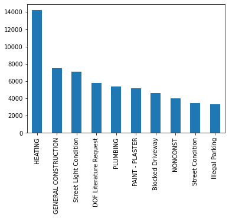

```python
ctcounts[:10].plot(kind="bar") # bar plot of the top 10 complaints
# call the plot method on a Series object
```

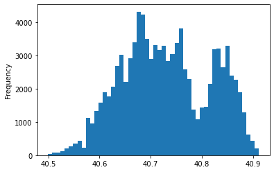

```python
complaints["Latitude"].plot(kind="hist", bins=50) # histogram of complaints by latitude
```

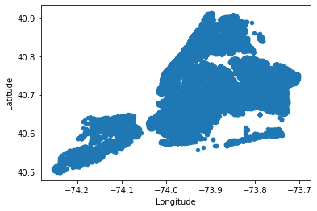

```python
complaints.plot(kind="scatter", x="Longitude", y="Latitude") # scatter plot by latitude and longitude
```

We can also look just at the "Heating" complaints using boolean array indexing.

```python
heat = complaints["Complaint Type"] == "HEATING"
```

`heat` is a series of True/False values, but we can plug this into square brackets in our DataFrame to only get the rows that meet that condition:

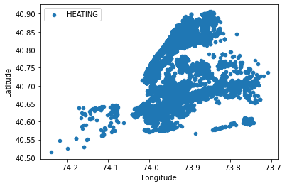

```python
complaints[heat].plot(kind="scatter", x="Longitude", y="Latitude", label="HEATING")
```